# 生成AIでものづくり！

専修大学 国里愛彦

## 今日のゴール

- 生成AIで「今、何ができるのか」を知る
- 心理学研究に生成AIをどう活かせるかを知る
- 心理学に限らない創作（本・イラスト・サイト・ゲーム・音楽・動画）での使い道を知る
- Geminiを使って、実際に簡単なものを作ってみる

## 生成AIの進化は凄まじい

- 数ヶ月単位で「できないこと」が「できること」に変わる
- 2026年時点の主な生成AIモデル
  - 文章・司令塔：Gemini 3 / GPT-5系 / Claude
  - 画像：Nano Banana Pro (Gemini 3 Pro Image)
  - 動画：Sora 2 / Veo 3.1
  - 音楽：Suno v5.5 / Udio v1.5
- 今日紹介する内容も、半年後にはもっと簡単・高性能になっているはず

# 心理学研究 × 生成AI

## 研究のどのフェーズで使える？

研究の一連の流れの、ほぼすべてのフェーズで生成AIが「壁打ち相手」「作業補助」として使える

1. 文献収集・レビュー
2. 仮説探索・研究デザイン
3. 尺度・質問紙・実験刺激の作成
4. 予備調査（パイロット・シリコンサンプリング）
5. データ分析の補助
6. 論文執筆・校正

## ① 文献収集・レビュー

- NotebookLM：アップロードした論文だけを根拠に要約・Q&Aしてくれる（ハルシネーションが少ない）
  - 複数論文を横断して比較表（テーマ・主張・方法論）を自動作成
  - 音声で概要を聴ける「音声解説」機能も
- ChatGPT/Gemini/Claudeの検索機能：先行研究のざっくりした地図作り、未検討の条件・変数の洗い出し
- あくまで下調べ・整理用。引用の正確性は必ず自分で原典確認する

## ② 仮説探索・研究デザインの壁打ち

- 「見落とし候補の増幅器」として使う
  - 考えていなかった変数・調整変数・対立仮説を提案させる
  - 出てきた仮説を「検証する価値があるか」自分で評価・選別する
- 教示文・手続きの曖昧さチェック（参加者がどう誤読しうるか）を本番前にAIに指摘させる

## ③ 尺度・質問紙・実験刺激の作成

- 心理尺度項目のたたき台を生成
  - Golino先生のAI-GEINIE
- 実験刺激（シナリオ・ヴィネット）を複数のトーン（丁寧・高圧的・中立）で瞬時に作成
- 難易度・長さ・言い回しのバリエーションを自動調整
- 顔画像や人物写真も生成AIで作成可能

## ④ 予備調査・シリコンサンプリング

- LLMを「仮想参加者」として使い、本実験の前に条件を試す
  - 説明文が破綻していないか
  - 手続きが機能しそうか
- あくまで**本番前のパイロット代わり**。実際の人間データの代替にはならない（外的妥当性に限界）
- 合成データで質問紙の弱点を先に洗い出す、という使い方も

## ⑤ 質的データの分析支援

- インタビュー・自由記述のテーマ分析（thematic analysis）をAIが下支え
- 「assist-and-review」モデルが2026年時点の標準的な使い方
  - AIがコード・テーマ候補を提案 → 研究者が採用・修正・却下を判断
  - 解釈の最終判断は必ず人間が行う
- コードレベルの一致率はまだばらつきがある一方、テーマレベルの一致率は高い傾向

## ⑥ 論文執筆・校正・査読対策

- 英文校正・言い回しの改善（Claude・ChatGPTなど）
- 結果の解釈の叩き台作り、対立解釈の候補出し
- 「査読者役」を演じさせて、論理の穴・限界を先に指摘してもらう
- R/Pythonの分析コード作成・デバッグの補助

## 使うときの注意点

- ハルシネーション（もっともらしい嘘）は今でも起きる → 事実確認は自分の責任
- インタビューデータなど個人情報を含む生データをそのままAIに入れない（同意があっても不十分な場合がある）
- 尺度項目・刺激は必ず専門家によるチェックを経る
- 「AIが作った」ことを論文・報告書で開示するルールを確認する（投稿先の規定を確認）

# 創作活動 × 生成AI

## 心理学に限らず、何が作れる？

| ジャンル | 代表的なツール（2026年時点） |
| --- | --- |
| 文章・本 | Gemini / Claude / ChatGPT |
| イラスト・マンガ | Nano Banana Pro (Gemini) |
| ウェブサイト・アプリ | Gemini Canvas / AI Studio Build |
| ゲーム | Gemini / Rosebud AI |
| 音楽 | Suno v5.5 / Udio v1.5 |
| 動画 | Sora 2 / Veo 3.1 |

## 文章・本

- 小説：テーマ→プロット→キャラ設定→章分割→推敲、という流れで長編も生成可能に
  - AI小説が文学賞の最終選考に残る例も出てきている
- 絵本・詩・エッセイなど短い作品も対話しながら作成しやすい
- コツ：一気に完成させず、プロット→一章ずつ→フィードバックの繰り返しで質が上がる

## イラスト・マンガ

- Nano Banana Pro（Gemini 3 Pro Image）
  - 最大4K解像度、テキストも綺麗に描ける、カメラアングル・照明・色調まで指定可能
  - 同じキャラクターの顔を保ったまま、別ポーズ・別シーンを再生成できる
- マンガ制作もキャラの一貫性を保ちながらコマ・ネームを作れる段階に
- 2026年1月にはAI生成マンガが電子書籍ストアで1位になった例も

## ウェブサイト・アプリ

- Gemini Canvas / Google AI Studio「Build」
  - プロンプトを打つだけでHTML/CSS/JSのWebアプリを自動生成（vibe coding）
  - プレビューを見ながら「ここを直して」で対話的に改善
- コード知識がなくても、簡単なポートフォリオサイトやツールが作れる
- 他にも v0・Lovable などのAIウェブ制作サービスがある

## ゲーム

- Gemini：構造化されたアシスタントとして、企画・仕様固め・ダイアログ作成・デバッグまで伴走
- Rosebud AI：自然言語プロンプトでブラウザゲームを作れるノーコードサービス（Gemini/GPT/Claude対応）
- Firebaseと組み合わせれば、作ったゲームをその場で公開できる

## 音楽

- Suno v5.5：ボーカル品質・速度で市場をリード、ポップス系が得意
- Udio v1.5：48kHzステレオの高音質、特定2秒だけ再生成する「インペイント」機能あり、ジャズ・クラシック系が得意
- 歌詞とジャンルを指定するだけでフルの楽曲が数分で完成

## 動画

- Sora 2：最大25秒・1080p、セリフ/効果音/BGMまで含めた音声付き生成。UIが直感的で初心者向き
- Veo 3.1：風景・建築物などのフォトリアルな描写が得意、商用広告向き
- 「静止画→数秒動画」から「音声付きの演技をするシーン」まで進化した

## どのAIを使う？(専大)

- あまり周知されてないが、専修大学ではGeminiとMS Copilotが使える。
- [MS Copilot](https://copilot.microsoft.com/):`@edu.senshu-u.ac.jp`のアカウトでログインして使える
- [Gemii](https://gemini.google.com)：`@senshu-u.jp`のアカウトでログインして使える

## どのAIを使う？（専大以外）

- CopilotとGeminiでも足りるかもしれないけど、以下は無料でも使える。
- [Groq](https://groq.com/):高速に動作し、色々と高機能なオープンソースモデルを使える。無料枠もそこそこ使える（クレジットカード不要）
- [Github Copilot](https://github.com/features/copilot?locale=ja)：VSCodeというエディタと組み合わせて使うと便利。Github Educationの申請をして通っている方は無料である程度使える。
- 課金をしても良いならば、OpenAI(GPT)とAnthropic(Claude)も良い。

# チュートリアル

## Antigravity

- Antigravityは、GoogleのAIエージェント用IDE(VSCodeベース)
- ファイル操作・ターミナル操作・ブラウザ操作まで自律的にこなしてくれる
- コードを書くだけでなく、実行結果の確認や簡易的なWeb操作までAIエージェントに任せられる
- 専修大学が契約しているGoogleアカウントで使える

## Antigravity IDEのインストール

- [Antigravityのサイト](https://antigravity.google/product/antigravity-ide)にいって、ダウンロードする。なお、AntigravityとAntigravity CLIとAntigravity IDEなどがあってややこしいが、今回は、Antigravity IDEをダウンロードする。
- ダウンロードとインストールを実施する。

[figure not shown]

## Antigravity IDEの起動

- (1)大学のGeminiアカウント（`@senshu-u.jp`）でChromeなどのウェブブラウザにログインする。
- (2)Continue with Googleをクリックする。

[figure not shown]

## アカウントの選択

- 自分の大学のGeminiアカウント（`@senshu-u.jp`）を選択する。

[figure not shown]

## ログイン

- 自分の大学のGeminiアカウント（`@senshu-u.jp`）にログインする。

[figure not shown]

## Antigravity IDEの起動

- Antigravity IDEを開くか聞かれるので、開きます。

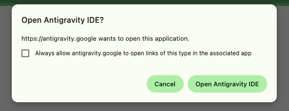

## Antigravity IDEの設定(1)

- ログインできて、認証されたら、Nextをクリック

[figure not shown]

## Antigravity IDEの設定(2)

- Start freshを選択して、Nextをクリック

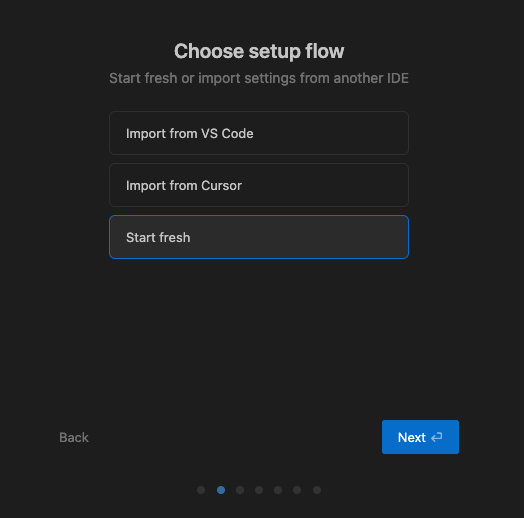

## Antigravity IDEの設定(3)

- 好みのテーマを選択して(DarkかLightか)、Nextをクリック

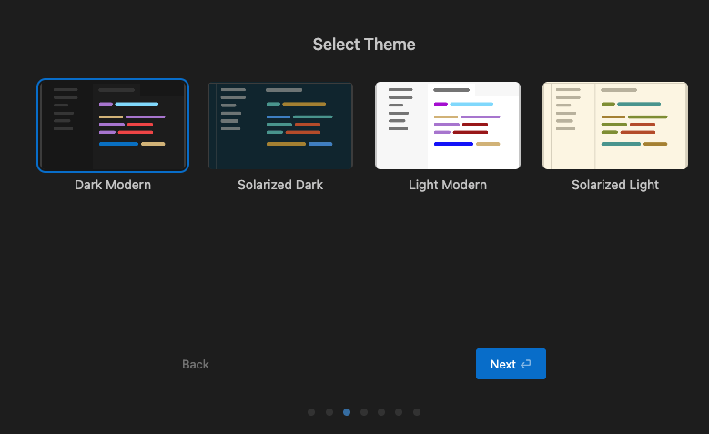

## Antigravity IDEの設定(4)

- RecommendedのReview-driven developmentを選択して、Nextをクリック

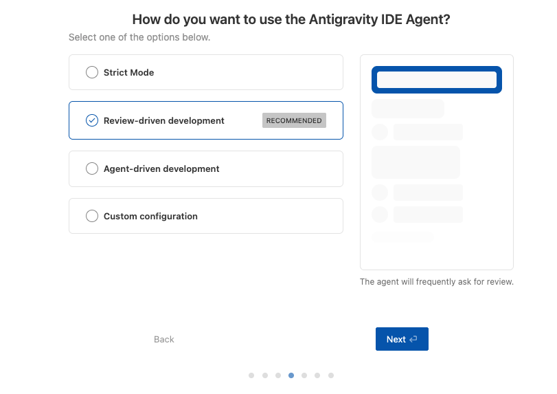

## Antigravity IDEの設定(5)

- 基本的にはデフォルトのままでよいので、Nextをクリック

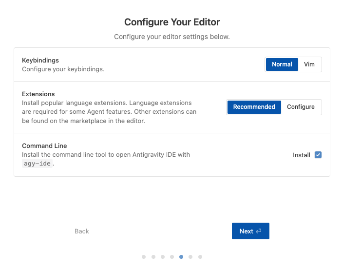

## Antigravity IDEの設定(6)

- Modern Web Guidance, Google Antigravity SDK, Science, Chrome DevToolsあたりをクリックしてから、Nextをクリック

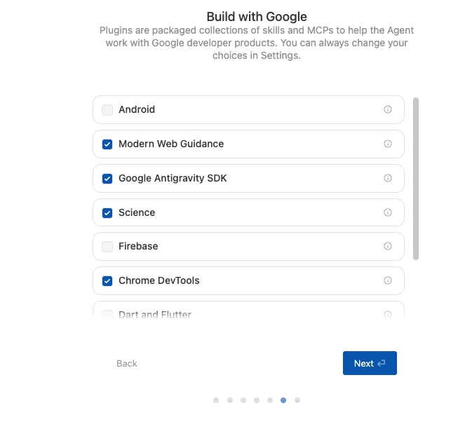

## Antigravity IDEの設定(7)

- 上を選んで、Nextをクリック

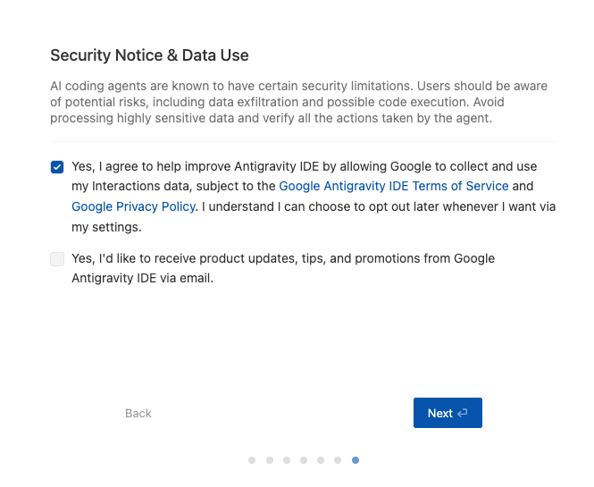

## Antigravity IDEの起動

- Antigravity IDEは、VSCodeベースになり、真ん中でファイルを操作でき、右側のバーでAIに指示を出す。
- Open Folderをクリックして、作業する場所を選択する（重要なファイルがある場所は選ばないでください、何もファイルが入ってないフォルダを新規作成して選ぶのが良いです）。

[figure not shown]

## 作業場所の承認

- 作業場所を開いてよいのか聞いてくるので、Yesを選択する

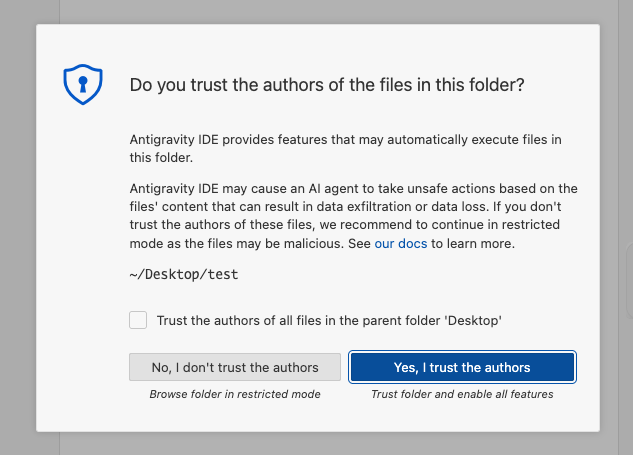

## Antigravity IDEの見た目

- 真ん中でファイルを操作でき、右側のバーでAIに指示を出す。

[figure not shown]

## 生成AIへの指示

- 右側のバーでAIに以下の指示（プロンプト）をだす。

> シンプルな反応時間ゲームをHTML/CSS/JavaScriptで1ファイルで作ってください。画面が「待って…」の状態からランダムなタイミングで緑色に変わったら、できるだけ早くクリックします。反応時間をミリ秒で表示し、5回プレイした平均も出してください。デザインはポップでかわいい感じにしてください。

## 生成AIへの指示

[figure not shown]

## 生成AIの作業の承認

- 生成AIがゴソゴソと作業をして、時に、こちらに承認を求めてきます。内容を確認して、選択して、Submitください。

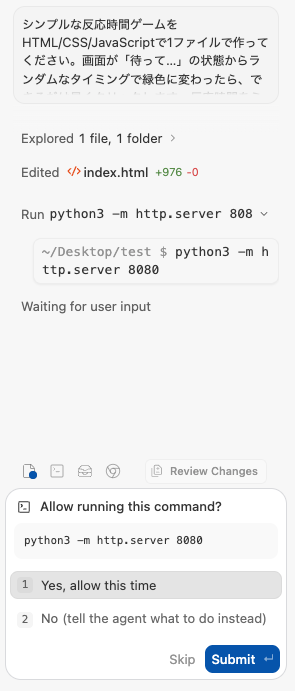

## 生成AIの作業後

- index.htmlファイルができました。HTMLファイルはウェブサイトで使われるファイル形式になり、JavaScriptを組み合わせるとちょっとしたゲームも作れます。

[figure not shown]

## index.htmlの開き方

- index.htmlは作業しているフォルダに勝手にできているので、それをブラウザで開けばいいのですが、一応生成AIに簡単に開く方法をお願いしたら、開き方を教えてくれたりします。

[figure not shown]

## できたゲームの確認

- ただのボタン押しだけど、デザインが結構楽しい感じになった。

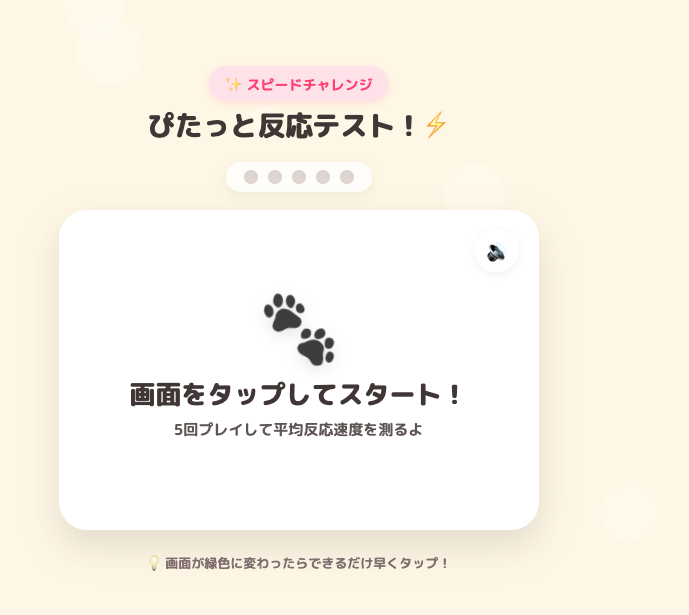

## 改良してみよう

生成されたら、そのままにせず追加のお願いをして育てていく

- 「早すぎてクリックしたら“早すぎぃ!”と表示して」
- 「効果音を追加して」
- 「5回分の記録をグラフで表示して」
- 「配色を専修大学っぽい青系にして」

## チュートリアル２：自己紹介ページを作る

- 新しいチャットを開いて、以下を入力

> 自己紹介用のおしゃれな1ページのホームページをHTML/CSSで作ってください。名前・趣味・好きな研究テーマを紹介するセクション、プロフィール写真のプレースホルダー、グラデーション背景、スクロール時のふわっとしたアニメーションを入れてください。

## 仕上げてみよう

- 「フォントをもっと読みやすい丸ゴシックにして」
- 「配色を〇〇（好きな色）系に変えて」
- 画像をアップロードして「この写真をプロフィール写真の場所に使って」
- 気に入ったら、コードをダウンロード／公開して完成

## 合宿中で何を作ろうか？

- おもしろいゲームを作る
- 心理学実験をベースにゲームを作る
- イラストや動画を作ってなにか作品を作る
- 心理学で使えそうなアプリを作る
- 日常生活であると便利なアプリを作る
- 自分のウェブサイトを作ってすごく豪華にする

# 発展的な話題

## AIをうまく使う4つの視点

- **プロンプトエンジニアリング**：AIへの指示の出し方を工夫すること（目的、出力形式、制約、評価基準を書くと精度が上がる）
- **コンテキスト**：AIに渡す前提情報のこと（論文PDF、対象者、目的、過去のやりとりなどの情報を渡す）
- **ハーネス**：AIを安全・安定して使うための枠組み（テンプレート、チェックリスト、テスト、参照資料の限定）
- **ループ**：1回で終わらせず、生成→確認→修正を繰り返すこと

## 実際にはどう組み合わせる？

- 1. まず目的を決めて、よい**プロンプト**を書く
- 2. 必要な資料や条件を**コンテキスト**として渡す
- 3. 出力の形式や確認方法を**ハーネス**で固定する
- 4. 結果を見て追加指示を出す**ループ**を回す

## 具体例

- たとえば「心理学実験の説明文を作る」なら
  - 対象者、実験目的、語調、文字数を指定する
  - 既存の説明文や倫理上の注意点を渡す
  - 「専門用語を避ける」「誤解しそうな箇所を指摘する」と確認条件を置く
  - そのうえで何度か修正して、実用レベルに近づけていく